# act_report

#### Insight 1

The rating of the dogs are not related to its retweet count or favorite count, suggesting that most of ratings are objective and does not represent the public opinions. However, retweet count and favorite count are highly correlated.

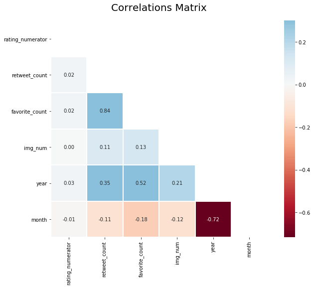

#### Insight 2

For the general dataset, pupper is the largest category with a percentage of 67.4.

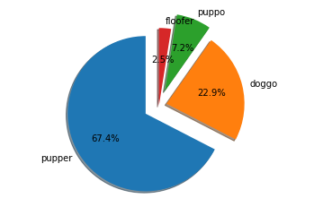

However, for the top 100 favorited tweets, doggo is the largest category and thre is no floofer.

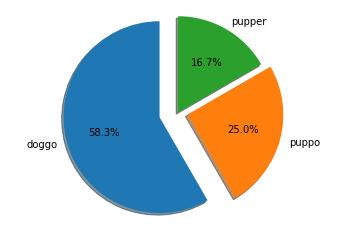

The most popluar dog breeds are golden_retrievers among the top favorited tweets

[figure not shown]

golden_retriever 12 Labrador_retriever 8 French_bulldog 8 Lakeland_terrier 4 standard_poodle 4 flat-coated_retriever 4 toy_poodle 4 Eskimo_dog 4 Rottweiler 4 whippet 4 Bedlington_terrier 4 chow 4 Chesapeake_Bay_retriever 4 cocker_spaniel 4 Pomeranian 4 English_springer 4 malamute 4

#### Insight 3

Year 2016 is when most tweets are published and most tweets are favorited and retweeted.

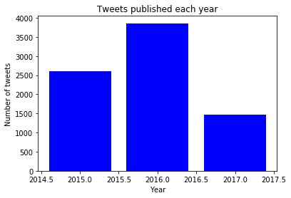

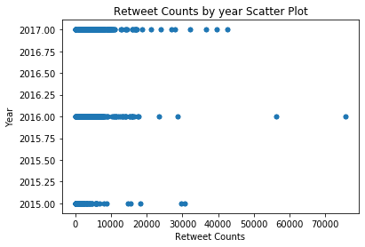

# wrangle_report

## Introduction

For this dataset, I used the tweet archive data obtained from the Twitter user @dog_rates,from 2015-2017. WeRateDogs has over 4 million followers and has received international media coverage.

## Gathering data

I started by gathering three datasets from three different sources as described below.

##### The WeRateDogs Twitter archive

This data comes from a csv files that contains basic information, including user id, timestamp and retweet information that is downloaded from the project website. I used pd.read_csv to extract this data.

##### The image prediction tsv file

This data comes from a tsv files that predicts the dogs breed using a neural network. This tsv file was extracted using url from the Udacity server using request.gets(url)

##### Access data from tweeter API

For this data, I accessed and stored each tweet's retweet count and favorite information to tweet_json. To access the information, I setup tweepy to authenticate with Twitter credentials using tweepy.OAuthHandler and created the api to connect to twitter with my account.

## Accessing data

By visualizing the datasets in general and sampling some data in depth, I checked the quality and tidiness of the datasets. Quality issues: completeness, validity, accuracy, consistency

1. Change all id to str object
2. Get rid of columns that won't be used for analysis
3. Change all time column to datetime object
4. Since some tweets did not have images ( and has NaN values for expanded_urls ), should remove those data.
5. There are some numbers that doesn't make senses (out of range) for the denominators and numerators.
6. There are decimal numbers in the rating, which are wrongly interpreted and need to be changed manually
7. There are duplicated images in the image prediction (and there are images that are not dogs)
8. There are repetitive columns (such as id and id_str, in_reply_to_status_id and in_reply_to_status_id_str )

Tidiness issues:

1. For twitter archive: the 4 stage columns (dogger, floofer, pupper and puppo) can be reduced to one columns
2. There are columns that shows none, instead of NaN. Should be make consistent.
3. For image prediction, combine the confidence columns.
4. Should merge all three datasets by tweet id.

## Cleaning data

Looking through the issues that were identified, I rearrange the issue by the time required to solve. For example, I first changed the datatype of tweet id so I can merge the three datasets. After merging the three datasets, I can avoid some repetitive work, such as gettting rid of unwanted columns and removing replicates. Then I combined columns with same type of information and also added in some data for later analysis. I also make a different copy for some step so that I can easily retrieve some data if any mistakes were made in a intermediate step.

In conclustion, during this process, I learnt several tools for data wrangling. Also, I familarize myself with many sources of help, such as Udacity, stackoverflow and github.